# Part II - Possible impact of sociodemographic characteristics on performance of students

## by Mbang Ernest Ngong

## Investigation Overview

Here we are particularly interested in undertsanding the countries that had the most participation in the PISA 2012 survey, furthermore, we are intersted in the effort that students put in in studying mathematics across sexes( male and female) and we are finally interested in undertanding the effect of class repetition on the reading strength of students. On our last interest, we are also interested in having this undertsanding among sexes(males and females).

## Dataset Overview

This analyis comprises drawing insight from the PISA dataset. The PISA dataset is part of the OECD's Programme for International Student Assessment .The PISA survey is a survey of students' skills and knowledge as they approach the end of compulsory education. Its main aim is to examine how well students have learned the school curriculum and how well they are prepared for life beyond school. It is made up of more than 600 variables that access these objectives. For this presentation we used just a part of the dataset.

## Top 5 countries with most participation in the 2012 PISA survey

The PISA 2012 survey saw a participation from over 65 countries, the Top 5 countries that recorded most participation were Mexico, Italy, Spain, Canada and Brasil in decreasing magnitude. several factors could be responsible for the reason why top participation was from these countries perhaps accessibility is a factor.

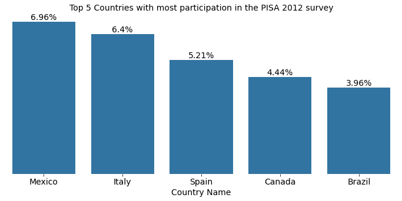

## Math reasoning effort by students across 68 countries

Effort and interest is vital for success in every field or subject. It appears that enthusiasm or lack of enthusiams cuts across both sexes(males and females) when it comes to math reasoning effort. This can be cleraly seen in the PISA survey as there is relatively a small difference between sexes at each category ranging from frequently to Never.

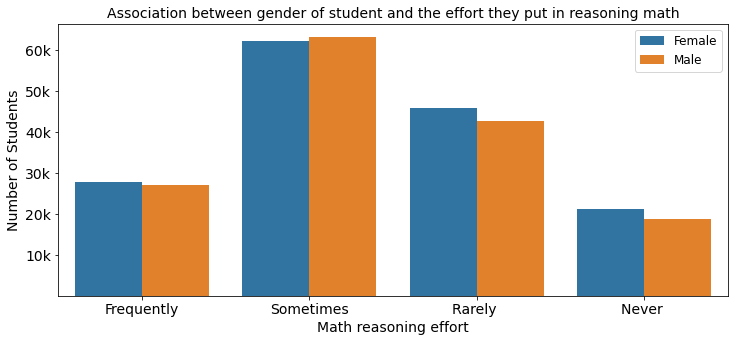

## Effect of class repetition on the reading strength of boys and girls.

It is common knowledge that the more a student is consistent with school and classes, the more likely they are to perform well academically, this is clearly seen in the PISA survey as reading strength reduces across both sexes with increased school repetitions with a slight decrease in reading strength among males.

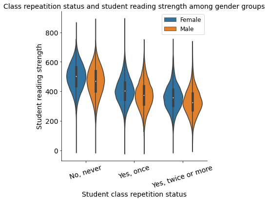